# ジオコーディングによる犯罪発生情報の可視化

神奈川県の例

[岩田真一郎](https://shinichiro-iwata.github.io/)（ [神奈川大学経済学部](https://www.econ.kanagawa-u.ac.jp/)）

2022-07-22作成，2025-03-01改定

# 1 目的

[ジオコーディング](https://ja.wikipedia.org/wiki/%E3%82%B8%E3%82%AA%E3%82%B3%E3%83%BC%E3%83%87%E3%82%A3%E3%83%B3%E3%82%B0)（アドレスジオコーディング，アドレスマッチングともいう）とは，住所情報を使って対応する緯度経度（ジオコード）を付加することをいう．

- 防犯対策推進を目的に，都道府県別の[犯罪オープンデータ](https://www.npa.go.jp/toukei/seianki/hanzaiopendatalink.html)が都道府県警察により公開されている．公開されている犯罪発生情報は「ひったくり」，「車上ねらい」，「自動販売機ねらい」，「自動車盗」，「自転車盗」など．
- 発生地の情報については，市区町村コードの他，「都道府県」，「市区町村」，「町丁目（空欄の場合もある）」が記載されている（発生地はジオコーディングによって点で示されるが，発生付近）．
- ここでは，神奈川県警察の[オープンデータサイト](https://www.police.pref.kanagawa.jp/mes/mesd0145.htm)から犯罪発生情報をダウンロードし，発生地点及び発生分布を可視化．

パッケージ：`sf`，`tidyverse`

```r
library(sf)
library(tidyverse)
```

# 2 ジオコーディング

**境界データのダウンロード**

- [国土数値情報ダウンロードサービス](https://nlftp.mlit.go.jp/ksj/) > 行政区域（ポリゴン） > 神奈川県 > 令和3年

```r
Kanagawa_map <-
  read_sf("N03-20210101_14_GML/N03-21_14_210101.shp")
```

**犯罪オープンデータのダウンロード**

**自動車盗**

- [犯罪オープンデータ リンク集｜警察庁Webサイト](https://www.npa.go.jp/toukei/seianki/hanzaiopendatalink.html) > 神奈川県 > [神奈川県警察オープンデータサイト](https://www.police.pref.kanagawa.jp/mes/mesd0145.htm) > 自動車盗 > 平成30年発生（csv 48KB）

```r
car_theft <-
  read.csv("kanagawa_2018zidousyatou.csv",
                    fileEncoding="CP932")

#自動車盗の中身
car_theft %>%
  head()
```

|  | 罪名 | 手口 | 管轄警察署.発生地. | 管轄交番.駐在所.発生地. | 市区町村コード.発生地. | 都道府県.発生地. | 市区町村.発生地. | 町丁目.発生地. | 発生年月日.始期. | 発生時.始期. | 発生場所の属性 | 施錠関係 | 盗難防止装置の有無 | 現金以外の主な被害品 |
| --- | --- | --- | --- | --- | --- | --- | --- | --- | --- | --- | --- | --- | --- | --- |
| 1 | 窃盗 | 自動車盗 | 南 | 南太田 | 141054 | 神奈川県 | 横浜市南区 | 清水ケ丘 | 2018-12-08 | 17 | 一戸建住宅 | キーあり | なし | 貨物自動車 |
| 2 | 窃盗 | 自動車盗 | 南 | 浦舟町 | 141054 | 神奈川県 | 横浜市南区 | 高根町３丁目 | 2018-01-28 | 01 | 道路上 | キーあり | なし | 貨物自動車 |
| 3 | 窃盗 | 自動車盗 | 大和 | 大和駅前 | 142131 | 神奈川県 | 大和市 | 草柳１丁目 | 2018-05-27 | 18 | ４階建て以上共同住宅 | キーあり | なし | 乗用自動車 |
| 4 | 窃盗 | 自動車盗 | 大和 | 福田 | 142131 | 神奈川県 | 大和市 | 代官２丁目 | 2018-09-03 | 23 | その他 | キーあり | あり | 乗用自動車 |
| 5 | 窃盗 | 自動車盗 | 大和 | 福田 | 142131 | 神奈川県 | 大和市 | 福田 | 2018-06-12 | 23 | 道路上 | キーあり | なし | 乗用自動車 |
| 6 | 窃盗 | 自動車盗 | 大和 | 深谷 | 142182 | 神奈川県 | 綾瀬市 | 深谷南５丁目 | 2018-03-26 | 18 | その他 | キーあり | なし | 貨物自動車 |

**ジオコーディング**

`car_theft`の6列目（都道府県），7列目（市区町村），8列目（町丁目）に発生地の情報がある．これを使い，ジオコーディング．

- [東京大学空間情報科学研究センター](https://www.csis.u-tokyo.ac.jp/)が提供する[CSVアドレスマッチングサービス](https://geocode.csis.u-tokyo.ac.jp/home/csv-admatch/)を利用．
- 詳細は[チュートリアル](https://geocode.csis.u-tokyo.ac.jp/home/csv-admatch/#tutorial)を参照．
- [CSVアドレスマッチングサービス](https://geocode.csis.u-tokyo.ac.jp/geocode-cgi/geocode.cgi?action=start)から**パラメータ設定**．ジオコード付きのデータを作成．
  - 対象範囲：神奈川県街区レベル（経緯度・世界測地系）．
  - 住所を含むカラム番号：6,7,8
    - `6`列目，`7`列目，`8`列目にあることを指示．
  - 「その他」は初期値（デフォルト）のままでおそらく大丈夫．
  - 変換したいファイル名：`kanagawa_2018zidousyatou.csv`を選択し，送信．
  - ダウンロードしたファイルは`kanagawa_2018zidousyatou_1.csv`として保存．
    - 再度，`car_theft`としてファイルを読込（`read.csv()`）．
    - `fX`が経度，`fY`が緯度が新たに加わったことが確認できる．

```r
car_theft <-
  read.csv("kanagawa_2018zidousyatou_1.csv",
           fileEncoding="CP932")

#自動車盗の中身
car_theft %>%
  head()
```

|  | 罪名 | 手口 | 管轄警察署.発生地. | 管轄交番.駐在所.発生地. | 市区町村コード.発生地. | 都道府県.発生地. | 市区町村.発生地. | 町丁目.発生地. | 発生年月日.始期. | 発生時.始期. | 発生場所の属性 | 施錠関係 | 盗難防止装置の有無 | 現金以外の主な被害品 | LocName | fX | fY | iConf | iLvl |
| --- | --- | --- | --- | --- | --- | --- | --- | --- | --- | --- | --- | --- | --- | --- | --- | --- | --- | --- | --- |
| 1 | 窃盗 | 自動車盗 | 南 | 南太田 | 141054 | 神奈川県 | 横浜市南区 | 清水ケ丘 | 2018/12/8 | 17 | 一戸建住宅 | キーあり | なし | 貨物自動車 | 神奈川県/横浜市/南区/清水ケ丘 | 139.6078 | 35.43979 | 5 | 5 |
| 2 | 窃盗 | 自動車盗 | 南 | 浦舟町 | 141054 | 神奈川県 | 横浜市南区 | 高根町３丁目 | 2018/1/28 | 1 | 道路上 | キーあり | なし | 貨物自動車 | 神奈川県/横浜市/南区/高根町/三丁目 | 139.6249 | 35.43668 | 5 | 6 |
| 3 | 窃盗 | 自動車盗 | 大和 | 大和駅前 | 142131 | 神奈川県 | 大和市 | 草柳１丁目 | 2018/5/27 | 18 | ４階建て以上共同住宅 | キーあり | なし | 乗用自動車 | 神奈川県/大和市/草柳/一丁目 | 139.4546 | 35.46588 | 5 | 6 |
| 4 | 窃盗 | 自動車盗 | 大和 | 福田 | 142131 | 神奈川県 | 大和市 | 代官２丁目 | 2018/9/3 | 23 | その他 | キーあり | あり | 乗用自動車 | 神奈川県/大和市/代官/二丁目 | 139.4572 | 35.44180 | 5 | 6 |
| 5 | 窃盗 | 自動車盗 | 大和 | 福田 | 142131 | 神奈川県 | 大和市 | 福田 | 2018/6/12 | 23 | 道路上 | キーあり | なし | 乗用自動車 | 神奈川県/大和市/福田 | 139.4604 | 35.44439 | 5 | 5 |
| 6 | 窃盗 | 自動車盗 | 大和 | 深谷 | 142182 | 神奈川県 | 綾瀬市 | 深谷南５丁目 | 2018/3/26 | 18 | その他 | キーあり | なし | 貨物自動車 | 神奈川県/綾瀬市/深谷南/五丁目 | 139.4442 | 35.43134 | 5 | 6 |

**発生地点の可視化**

`ggplot()`で発生地点を可視化．

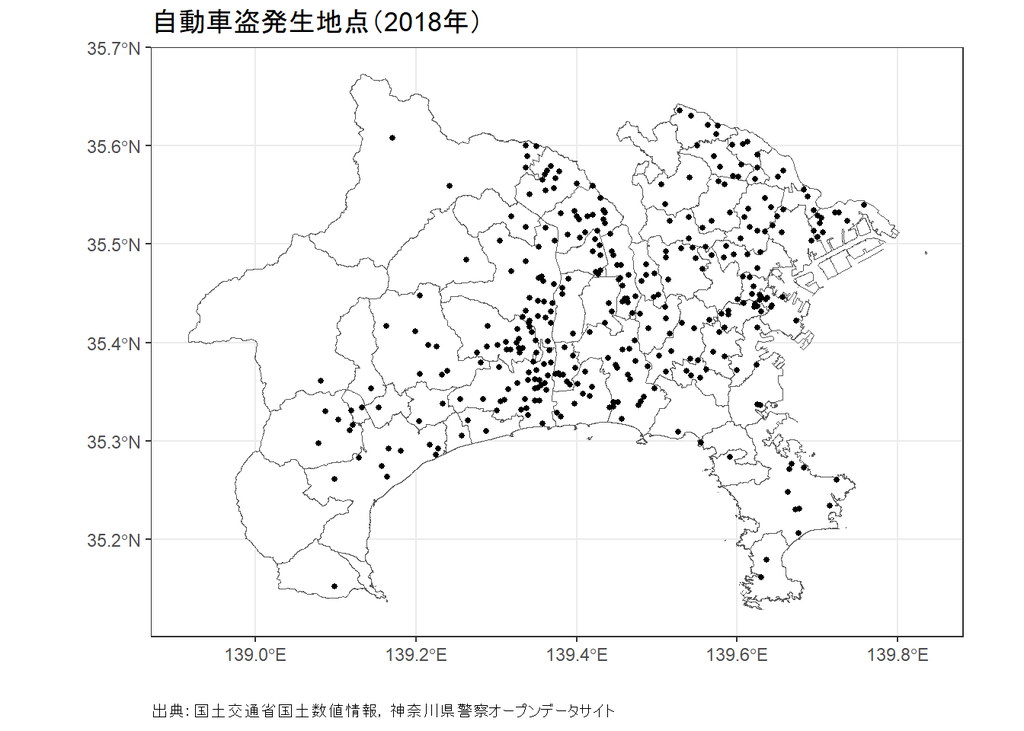

```r
ggplot()+
  geom_sf(data=Kanagawa_map, fill="white")+
  geom_point(data=car_theft, aes(x=fX, y=fY),
             size=1)+
  labs(x="", y="",
  caption="出典：国土交通省国土数値情報，神奈川県警察オープンデータサイト")+
  ggtitle("自動車盗発生地点（2018年）")+
  theme_bw()+
  theme(plot.caption=element_text(hjust=0))
```

# 3 応用

## 3.1 ヒートマップ

点が密集している場所では自動車盗が多いことが予想されるが，**同じ**発生地点で自動車盗が複数回起きている場合は点が完全に重なり，地図上では複数回起きていることを確認できない．

- これを回避する方法として，ポイントデータの周辺（領域）を自動車盗数に応じて色分けする方法が挙げられる．ここでは，[`geom_bin2d()`](https://ggplot2.tidyverse.org/reference/geom_bin_2d.html)と[`stat_density_2d()`](https://ggplot2.tidyverse.org/reference/geom_density_2d.html)を使い，色分けする．
  - `geom_bin2d()`：長方形（タイル）の領域をつくり，その領域内の自動車盗数に応じて色を付ける．このような地図は[ヒートマップ](https://ja.wikipedia.org/wiki/%E3%83%92%E3%83%BC%E3%83%88%E3%83%9E%E3%83%83%E3%83%97)（密度マップ）とよばれる．

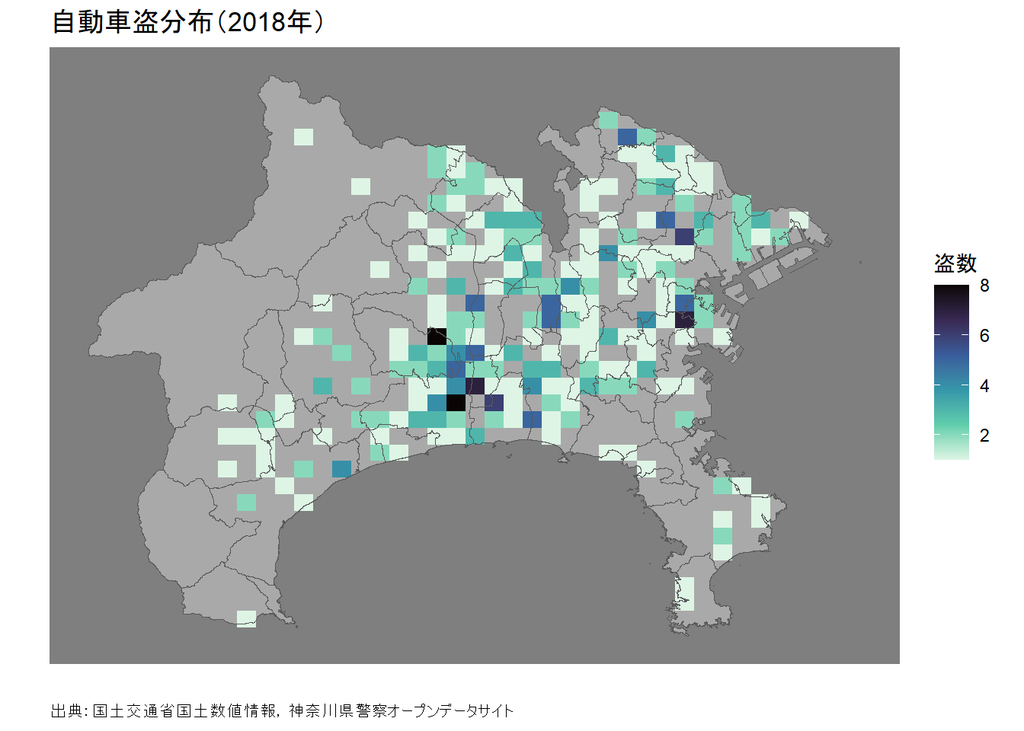

```r
ggplot()+
  geom_sf(data=Kanagawa_map, fill="dark gray")+
  geom_bin2d(data=car_theft, aes(x=fX, y=fY))+
  scale_fill_viridis_c(option="G",
                       direction=-1)+
  geom_sf(data=Kanagawa_map, fill="NA")+
    labs(fill="盗数", x="", y="",
  caption="出典：国土交通省国土数値情報，神奈川県警察オープンデータサイト")+
  ggtitle("自動車盗分布（2018年）")+
  coord_sf(datum=NA)+
  theme_dark()+
  theme(plot.caption=element_text(hjust=0))
```

**カーネル密度推定**

- `stat_density_2d()`：ポイントのない地点も含め，より連続的な領域を考え，色分けする．領域内の自動車盗数は[カーネル密度推定](https://ja.wikipedia.org/wiki/%E3%82%AB%E3%83%BC%E3%83%8D%E3%83%AB%E5%AF%86%E5%BA%A6%E6%8E%A8%E5%AE%9A)によって求める．
  - `fill=stat(level)`：色分けをレベル（この場合，自動車盗数）の違いに応じて行うように指示．
  - `geom="polygon"`：領域を色分けするように指示．このオプションを指示しない場合は，同色の等高線が表示．
  - `bins=7`：階級（ビン）数の指定．このオプションを指示しないことも考えられるが，階級が多すぎると雑然とした印象．連続にならない箇所も出現．
- `theme_dark()`：背景を暗くするように指示．

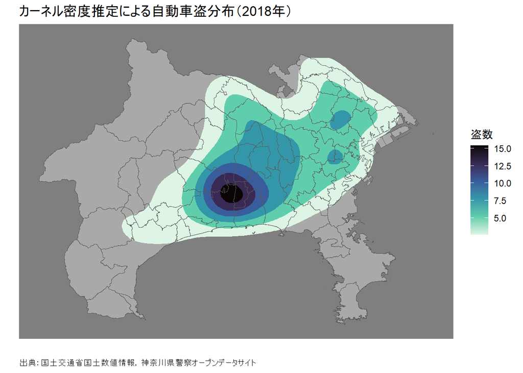

```r
ggplot()+
  geom_sf(data=Kanagawa_map, fill="dark gray")+
  stat_density_2d(data=car_theft,
                  aes(x=fX, y=fY,
                      fill=after_stat(level)),
                  geom="polygon", bins=7)+
  scale_fill_viridis_c(option="G",
                       direction=-1)+
  geom_sf(data=Kanagawa_map, fill="NA")+
  labs(fill="盗数", x="", y="",
  caption="出典：国土交通省国土数値情報，神奈川県警察オープンデータサイト")+
  ggtitle("カーネル密度推定による自動車盗分布（2018年）")+
  coord_sf(datum=NA)+
  theme_dark()+
  theme(plot.caption=element_text(hjust=0))
```

- `bins`を指定しない場合．

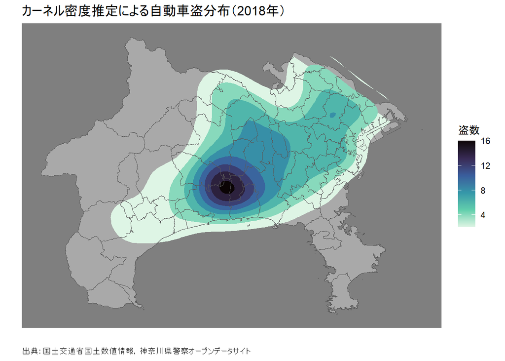

```r
ggplot()+
  geom_sf(data=Kanagawa_map, fill="dark gray")+
  stat_density_2d(data=car_theft,
                  aes(x=fX, y=fY,
                      fill=after_stat(level)),
                  geom="polygon")+
  scale_fill_viridis_c(option="G",
                       direction=-1)+
  geom_sf(data=Kanagawa_map, fill="NA")+
  labs(fill="盗数", x="", y="",
  caption="出典：国土交通省国土数値情報，神奈川県警察オープンデータサイト")+
  ggtitle("カーネル密度推定による自動車盗分布（2018年）")+
  coord_sf(datum=NA)+
  theme_dark()+
  theme(plot.caption=element_text(hjust=0))
```

**自転車盗の発生地点とカーネル密度推定の可視化**

平成30年発生の自転車盗は点の重っている地点が多く，密集もしている．

- コードは繰り返しのため示さない．

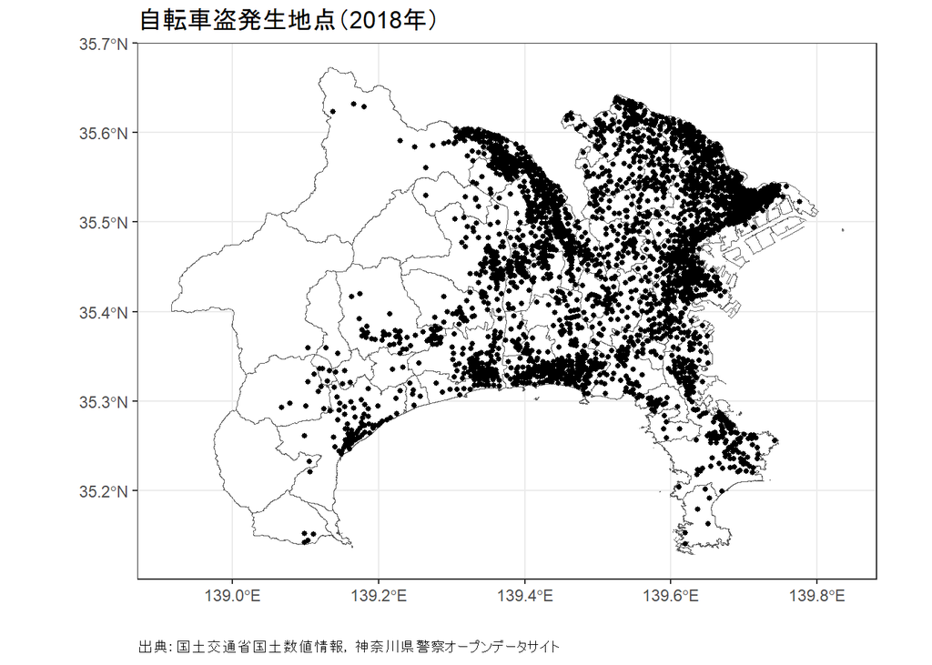

自転車盗の分布（カーネル密度推定）は次のような地図になる．

- 緯度経度付きのオブジェクトを`bicycle_theft`と名付けた．
  - 階級（`bins`）のオプションは外して可視化．

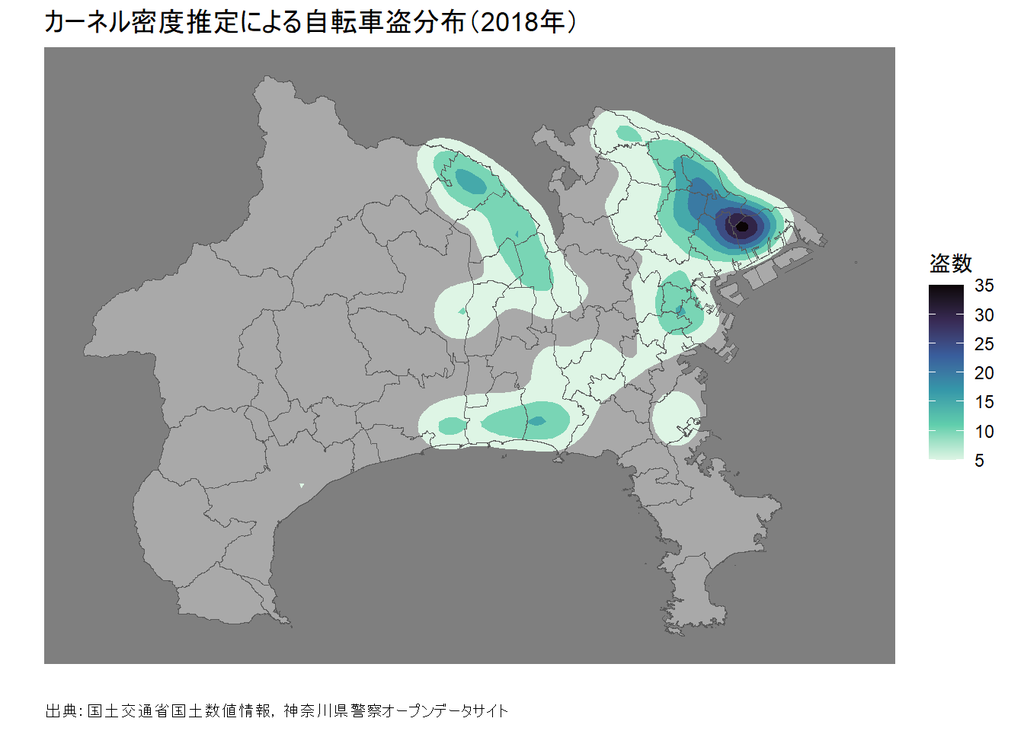

```r
ggplot()+
  geom_sf(data=Kanagawa_map, fill="dark gray")+
  stat_density_2d(data=bicycle_theft,
                  aes(x=fX, y=fY,
                      fill=after_stat(level)),
                  geom="polygon")+
  scale_fill_viridis_c(option="G",
                       direction=-1)+
  geom_sf(data=Kanagawa_map, fill="NA")+
  labs(fill="盗数", x="", y="",
  caption="出典：国土交通省国土数値情報，神奈川県警察オープンデータサイト")+
  ggtitle("カーネル密度推定による自転車盗分布（2018年）")+
  coord_sf(datum=NA)+
  theme_dark()+
  theme(plot.caption=element_text(hjust=0))
```

**Rによる地理空間データの可視化**

- チュートリアル[ホーム](https://shinichiro-iwata.github.io/geospatial-data-visualization/)

**アイコン**

[Font Awesome](https://fontawesome.com/) 6.7.2